# Unboxing the blackbox: Autograd

Date: May 31, 2020

Table of contents:

- What is Autograd?
- Reverse engineering simple functions
- Autograd for simple functions
- Reverse engineering complex, multidimensional functions
- Autograd for complex, multidimensional functions
- Afterword

Today, we will recreate probably the most useful tool that completely defines PyTorch: Autograd. The objective is to recreate every functionality of autograd only with basic tensor manipulation tools, without any PyTorch's other magical functions. The hope is to give you a sense of independence from the platform itself and a feeling that you can rebuild everything from scratch.

We have already seen how to build other basic components from scratch in a [previous post](http://blackbox.nn.157239n.com/basics), but we still use Autograd as a blackbox. The goal is to eliminate that last blackbox. So without further ado, let's import some stuff:

```python
import torch
import torch.nn as nn
import numpy as np
import matplotlib.pyplot as plt
import gc
%load_ext dotmagic
```

## What is Autograd?

Autograd is a mechanism to automatically calculate gradients as you do the math. For example, we have 4 variables, $a, b, c, d$, where $b = f(a); c=g(b); d=h(c)$. You only need to calculate $b, c, d$, and Autograd will automatically calculate for you $\frac{\partial d}{\partial a}, \frac{\partial d}{\partial b}, \frac{\partial d}{\partial c}$, which you can use directly in your optimizer.

Let's go through an example. Let's define a tensor drawn from the uniform distribution $U(0, 1)$:

```python
a = torch.rand(3).requires_grad_(True); a
```

```
tensor([0.3675, 0.8485, 0.8939], requires_grad=True)
```

Let's now calculate other values:

```python
b = 2 * a
c = torch.exp(b)
d = 3 + c
e = d.sum()
b, c, d, e
```

```
(tensor([0.7350, 1.6969, 1.7878], grad_fn=<MulBackward0>),
 tensor([2.0856, 5.4572, 5.9764], grad_fn=<ExpBackward>),
 tensor([5.0856, 8.4572, 8.9764], grad_fn=<AddBackward0>),
 tensor(22.5192, grad_fn=<SumBackward0>))
```

Now let's get the gradients:

```python
e.backward(); a.grad
```

```
tensor([ 4.1711, 10.9144, 11.9529])
```

So here,

- $b_i=2\cdot a_i$
- $c_i=e^{b_i}$
- $d_i=3+c_i$
- $e=\sum_i^3d_i$

Now, let's calculate the gradients by hand:

- $\frac{\partial e}{\partial d_i} = 1$
- $\frac{\partial e}{\partial c_i}=\frac{\partial e}{\partial d_i}\cdot\frac{\partial d_i}{\partial c_i}=1\cdot1=1$
- $\frac{\partial e}{\partial b_i}=\frac{\partial e}{\partial d_i}\cdot\frac{\partial d_i}{\partial c_i}\cdot\frac{\partial c_i}{\partial b_i}=1\cdot1\cdot e^{b_i}=e^{b_i}$
- $\frac{\partial e}{\partial b_i}=\frac{\partial e}{\partial d_i}\cdot\frac{\partial d_i}{\partial c_i}\cdot\frac{\partial c_i}{\partial b_i}\cdot\frac{\partial b_i}{\partial a_i}=1\cdot1\cdot e^{b_i}\cdot2=2e^{b_i}$

Let's check whether this is the same as `a.grad`:

```python
2*torch.exp(b)
```

```
tensor([ 4.1711, 10.9144, 11.9529], grad_fn=<MulBackward0>)
```

Yep, it has automatically calculate every gradients for us. This is pretty awesome right? When I was starting out with neural networks, I got really, really turned off whenever I have to manually calculate the partial derivatives for every function out there. I mean, for simple activations like ReLU, the derivative is easy. 0 or 1, and that's it. But for stuff like sigmoid, it seems like I have to derive the derivative equation by hand, then code that in somehow, and overall it's quite a mess. And people like other stuff too, like tanh, at which point I just gave up. The first time I heard about Autograd I couldn't believe it too. It streamlines everything so, so much, and now literally the sky is the limit.

## Reverse engineering simple functions

To implement our own solution, we will first see how the built in function handles it, and then try to replicate it, because I feel like you will understand it better that way. However, keep in mind that it's still possible to derive all of these through formal mathematical proofs. Let's check it out for several simple operations:

### Sum

```python
a = torch.rand(2, 3).requires_grad_(True); a
```

```
tensor([[0.9569, 0.1119, 0.8821],
        [0.1337, 0.3467, 0.8008]], requires_grad=True)
```

```python
b = a.sum(); b.backward(); b, a.grad
```

```
(tensor(3.2320, grad_fn=<SumBackward0>),
 tensor([[1., 1., 1.],
         [1., 1., 1.]]))
```

Okay, this one is pretty easy. You're just summing every element, so the partial derivative with respect to any element should just be 1. Note that the shape of `a` is exactly the same as `a.grad`.

### Multiplication with constant

```python
a = torch.rand(2, 3).requires_grad_(True); a
```

```
tensor([[0.3046, 0.0910, 0.1703],
        [0.8869, 0.4034, 0.2420]], requires_grad=True)
```

```python
b = 3 * a; b.sum().backward(); b, a.grad
```

```
(tensor([[0.9139, 0.2730, 0.5109],
         [2.6607, 1.2101, 0.7259]], grad_fn=<MulBackward0>),
 tensor([[3., 3., 3.],
         [3., 3., 3.]]))
```

This one is easy too. We know that $\frac{d}{dx}3x=3$, so the derivative is just the constant.

### Exponential

```python
a = torch.rand(2, 3).requires_grad_(True); a
```

```
tensor([[0.9606, 0.1768, 0.1235],
        [0.3507, 0.5444, 0.1972]], requires_grad=True)
```

```python
b = torch.exp(a); b.sum().backward(); b, a.grad
```

```
(tensor([[2.6132, 1.1934, 1.1314],
         [1.4201, 1.7235, 1.2180]], grad_fn=<ExpBackward>),
 tensor([[2.6132, 1.1934, 1.1314],
         [1.4201, 1.7235, 1.2180]]))
```

Again, we know that $\frac{d}{dx}e^x=e^x$, so `a.grad` should be exactly the same as `b`. Let's quickly try out other functions:

### Sine

```python
a = torch.rand(2, 3).requires_grad_(True); a
```

```
tensor([[0.5287, 0.7231, 0.6455],
        [0.5968, 0.3445, 0.9343]], requires_grad=True)
```

```python
b = torch.sin(a); b.sum().backward(); b, a.grad, torch.cos(a)
```

```
(tensor([[0.5044, 0.6617, 0.6016],
         [0.5620, 0.3377, 0.8042]], grad_fn=<SinBackward>),
 tensor([[0.8634, 0.7497, 0.7988],
         [0.8272, 0.9413, 0.5944]]),
 tensor([[0.8634, 0.7497, 0.7988],
         [0.8272, 0.9413, 0.5944]], grad_fn=<CosBackward>))
```

### Natural log

```python
a = torch.rand(2, 3).requires_grad_(True); a
```

```
tensor([[0.2774, 0.7380, 0.2010],
        [0.8901, 0.5569, 0.9714]], requires_grad=True)
```

```python
b = torch.log(a); b.sum().backward(); b, a.grad, 1/a
```

```
(tensor([[-1.2822, -0.3037, -1.6043],
         [-0.1164, -0.5853, -0.0290]], grad_fn=<LogBackward>),
 tensor([[3.6046, 1.3549, 4.9743],
         [1.1235, 1.7956, 1.0294]]),
 tensor([[3.6046, 1.3549, 4.9743],
         [1.1235, 1.7956, 1.0294]], grad_fn=<MulBackward0>))
```

Okay, now that you understand how this works, let's see a situation where multiple of these functions work together:

### Compose

```python
a = torch.rand(3).requires_grad_(True); a
```

```
tensor([0.2572, 0.0755, 0.9906], requires_grad=True)
```

```python
b = 2 * a; b
```

```
tensor([0.5145, 0.1510, 1.9812], grad_fn=<MulBackward0>)
```

```python
c = torch.exp(b); c
```

```
tensor([1.6728, 1.1630, 7.2512], grad_fn=<ExpBackward>)
```

```python
d = torch.sin(c); d
```

```
tensor([0.9948, 0.9180, 0.8237], grad_fn=<SinBackward>)
```

```python
e = d.sum(); e.backward(); e
```

```
tensor(2.7365, grad_fn=<SumBackward0>)
```

```python
a.grad, b.grad, c.grad, d.grad
```

```
(tensor([-0.3405,  0.9225,  8.2224]), None, None, None)
```

So now, the gradient of interest is $\frac{\partial e}{\partial a_i}=\frac{\partial e}{\partial d_i}\cdot\frac{\partial d_i}{\partial c_i}\cdot\frac{\partial c_i}{\partial b_i}\cdot\frac{\partial b_i}{\partial a_i}$. Individual terms:

- $\frac{\partial e}{\partial d_i}=1$
- $\frac{\partial d_i}{\partial c_i}=cos(c_i)$
- $\frac{\partial c_i}{\partial b_i}=e^{b_i}$
- $\frac{\partial b_i}{\partial a_i}=2$

So, $\frac{\partial e}{\partial a_i}=2\cdot cos(c_i)\cdot e^{b_i}$. Let's test it:

```python
2 * torch.cos(c) * torch.exp(b)
```

```
tensor([-0.3405,  0.9225,  8.2224], grad_fn=<MulBackward0>)
```

Yep, exactly the same as `a.grad`. Let's now build Autograd right away.

## Autograd for simple functions

Let's see the code right away, and I will explain it step by step right after this:

```python
def IdentityBackward(x1, x2, nextGrad): return (x1, None)
def ExpBackward(x1, x2, nextGrad): return (nextGrad * torch.exp(x1.data), None)
def SinBackward(x1, x2, nextGrad): return (nextGrad * torch.cos(x1.data), None)
def CosBackward(x1, x2, nextGrad): return (nextGrad * (-torch.sin(x1.data)), None)
def LogBackward(x1, x2, nextGrad): return (nextGrad * 1/x1.data, None)
def MulBackward(x1, x2, nextGrad): return (nextGrad * x2.data, nextGrad * x1.data)
def AddBackward(x1, x2, nextGrad):
    return (nextGrad * torch.ones(*x1.shape), nextGrad * torch.ones(*x2.shape))
def SumBackward(x1, x2, nextGrad): return (nextGrad * torch.ones(*x1.shape), None)
```

```python
class Tensor:
    def __init__(self, data, grad_fn=None):
        self.data = data; self.shape = data.shape
        self.requires_grad = False; self.grad_fn = grad_fn; self.grad = None
        self.x1, self.x2 = None, None # placeholders for dependent variables
    def requires_grad_(self, requires_grad):
        self.grad_fn = IdentityBackward if requires_grad else None
        self.requires_grad = requires_grad; return self
    def __repr__(self):
        return str(self.data)
    def sum(self, dim=None):
        if dim is not None:
            if self.grad_fn:
                answer = Tensor(self.data.sum(dim=dim), grad_fn=SumBackward)
                answer.x1 = self; return answer
            else: return Tensor(self.data.sum(dim=dim))
        if self.grad_fn:
            answer = Tensor(self.data.sum(), grad_fn=SumBackward)
            answer.x1 = self; return answer
        else: return Tensor(self.data.sum())
    def __add__(self, tensor):
        if type(tensor) in [int, float]: tensor = Tensor(torch.ones(*self.shape)*tensor)
        #if self.shape != tensor.shape: raise Exception("Incompatible shapes")
        if tensor.grad_fn or self.grad_fn:
            answer = Tensor(self.data + tensor.data, grad_fn=AddBackward)
            answer.x1 = self; answer.x2 = tensor; return answer
        else: return Tensor(self.data + tensor.data)
    def __radd__(self, tensor): return self.__add__(tensor)
    def __mul__(self, tensor):
        if type(tensor) in [int, float]: tensor = Tensor(torch.ones(*self.shape)*tensor)
        if self.shape != tensor.shape:
            raise Exception(f"Incompatible shapes: {self.shape}, {tensor.shape}")
        if tensor.grad_fn or self.grad_fn:
            answer = Tensor(self.data * tensor.data, grad_fn=MulBackward)
            answer.x1 = self; answer.x2 = tensor; return answer
        else: return Tensor(self.data * tensor.data)
    def __rmul__(self, tensor): return self.__mul__(tensor)
    def calculateGradientOfDependents(self):
        if self.grad_fn:
            gradX1, gradX2 = self.grad_fn(self.x1, self.x2, self.grad)
            # this is the chain rule part
            if type(self.grad) != type(None):
                if type(gradX1) != type(None): self.x1.grad = gradX1
                if type(gradX2) != type(None): self.x2.grad = gradX2
                # if doesn't retain gradientstrack track , then delete to free resources
                if not self.requires_grad: del self.grad; self.grad = None
            if type(self.x1) != type(None): self.x1.calculateGradientOfDependents()
            if type(self.x2) != type(None): self.x2.calculateGradientOfDependents()
    def backward(self):
        if len(self.shape) != 0:
            raise Exception(".backward() can only be called from rank 0 tensors")
        self.grad = 1; self.calculateGradientOfDependents()
        gc.collect()
class Utils:
    def __init__(self): pass
    def rand(self, *shape): return Tensor(torch.rand(shape))
    def zeros(self, *shape): return Tensor(torch.zeros(shape))
    def ones(self, *shape): return Tensor(torch.ones(shape))
    def exp(self, tensor: Tensor):
        if tensor.grad_fn:
            answer = Tensor(torch.exp(tensor.data), grad_fn=ExpBackward)
            answer.x1 = tensor; return answer
        else: return Tensor(torch.exp(tensor.data))
    def sin(self, tensor: Tensor):
        if tensor.grad_fn:
            answer = Tensor(torch.sin(tensor.data), grad_fn=SinBackward)
            answer.x1 = tensor; return answer
        else: return Tensor(torch.sin(tensor.data))
    def cos(self, tensor: Tensor):
        if tensor.grad_fn:
            answer = Tensor(torch.cos(tensor.data), grad_fn=CosBackward)
            answer.x1 = tensor; return answer
        else: return Tensor(torch.cos(tensor.data))
    def log(self, tensor: Tensor):
        if tensor.grad_fn:
            answer = Tensor(torch.log(tensor.data), grad_fn=LogBackward)
            answer.x1 = tensor; return answer
        else: return Tensor(torch.log(tensor.data))
utils = Utils()
```

Now let's test this against $f(x)=(e^x+3)\cdot4$. We can find its derivative: $\frac{d}{dx}(e^x+3)\cdot4=4e^x$

```python
a = utils.rand(2, 3).requires_grad_(True)
b = utils.exp(a)
c = b + 3
d = c * 4
e = d.sum(); e.backward()
a, b, c, d, e, a.grad, 4 * utils.exp(a)
```

```
(tensor([[0.8592, 0.8111, 0.6281],
         [0.5265, 0.7898, 0.4311]]),
 tensor([[2.3613, 2.2504, 1.8741],
         [1.6930, 2.2029, 1.5389]]),
 tensor([[5.3613, 5.2504, 4.8741],
         [4.6930, 5.2029, 4.5389]]),
 tensor([[21.4451, 21.0018, 19.4965],
         [18.7722, 20.8116, 18.1557]]),
 tensor(119.6829),
 tensor([[9.4451, 9.0018, 7.4965],
         [6.7722, 8.8117, 6.1557]]),
 tensor([[9.4451, 9.0018, 7.4965],
         [6.7722, 8.8117, 6.1557]]))
```

And the result is exactly that! Isn't it wonderful? Now let's understand what's going on.

First thing first, we're defining our own `Tensor` class. Just like `torch.Tensor`, `Tensor` will have 2 `torch.Tensor` objects. 1 is `data` for the main tensor and the other is `grad`, for the gradient of the main tensor. `grad` is set to None in the first place though, because there are no gradients initially. Only when we call `.backward()` will the gradient appear, and we can do things with it. `Tensor` will also have a `requires_grad` variable, to indicate that we should track and retain the gradient of this tensor. `requires_grad` can be set using the `.requires_grad_()` function, just like how `torch.Tensor` did it. All derived tensors from a tensor that retains the gradient tracks, but doesn't have to retain the gradients. Meaning, if $a$ has `requires_grad` set to true, and $b = sin(a), c = log(b)$, then $b$ and $c$ will track their own gradients, but don't have to retain the gradients.

The `Utils` class with an accompanying `utils` singleton object gives us a bunch of functions, to make it parallel to PyTorch's way of doing it. For example, `utils.exp()` looks and feels like `torch.exp()`. `Utils.rand()`, `Utils.zeros()` and `Utils.ones()` are pretty straightforward. It takes in a number of dimensions, and then creates a `Tensor` with data from the respective PyTorch's functions.

Now I want you to focus on `Utils.exp()`, `Utils.sin()`, `Utils.cos()`, and `Utils.log()`, but only the last line of each function, where the gradients are not tracked. `Tensor.grad_fn` is not `None` only if we have decided to track the gradient (but not necessarily retain it), and so we can use that to check whether we need to deal with all the gradient stuff for a particular operation or not. All of them look simple enough. We're just creating a new `Tensor` with the transformed data and returning it back. Pretty straightforward.

Let's jump into fire and look at this dynamic computational graph:

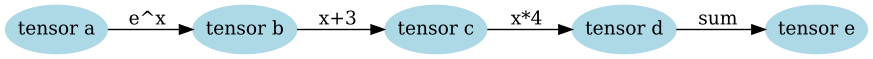

```python
%%dot -p
digraph {
    node [style="filled", color="lightblue"]; rankdir="LR"
    a [label="tensor a"]; b [label="tensor b"]; c [label="tensor c"]
    d [label="tensor d"]; e [label="tensor e"]
    a -> b [label="e^x  "]; b -> c [label="x+3  "]
    c -> d [label="x*4  "]; d -> e [label="sum  "]
}
```

Pretty sensible. The `Tensor.x1` and `Tensor.x2` variables hold the values of the previous step, and both of them will then be fed into `Tensor.grad_fn`, to obtain the local gradients ($\frac{d}{da}b, \frac{d}{dc}d$, ..., but not $\frac{d}{db}e, \frac{d}{da}c$, ...):

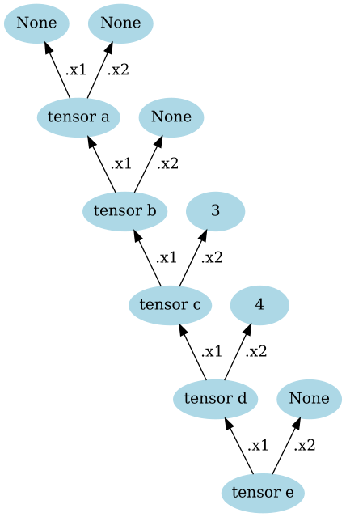

```python
%%dot -p
digraph {
    node [style="filled", color="lightblue"]; rankdir="BT"
    a [label="tensor a"]; b [label="tensor b"]; c [label="tensor c"]
    d [label="tensor d"]; e [label="tensor e"]
    Naa [label="None"]; Nab [label="None"]; Nb [label="None"]; Ne [label="None"]
    a -> Naa [label="  .x1"]; b -> a [label="  .x1"]; c -> b [label="  .x1"]
    d -> c [label="  .x1"]; e -> d [label="  .x1"]
    a -> Nab [label="  .x2"]; b -> Nb [label="  .x2"]; c -> 3 [label="  .x2"]
    d -> 4 [label="  .x2"]; e -> Ne [label="  .x2"]
}
```

They don't have to always have a value though. If the operation has 2 variables, like $y+z$, then `Tensor.x1` will point to $y$, and `Tensor.x2` will point to $z$. If the operation has 1 variable only, like $e^x$, then `Tensor.x1` will point to $x$, and `Tensor.x2` will point to `None`. If the operation has 0 variables (tensor initialization), like with tensor `a` above, then both `Tensor.x1` and `Tensor.x2` point to None.

Let's now zoom in and just consider tensors `a` and `b`. a's local gradient ($\frac{d}{da}b$) is just `b.grad_fn(a, None)`, but the global gradient ($\frac{d}{da}e$) will be `a.grad = b.grad_fn(a, None) * b.grad` ($\frac{d}{da}e=\frac{d}{da}b\cdot\frac{d}{db}e$). We can combine these behavior so that to get the global gradient we can call `a.grad = b.grad_fn(a, None, b.grad)` This logic is implemented in the `Tensor.calculateGradientOfDependents()` function. Then we can write `Tensor.backward()` as a wrapper function for that internal function, to deal with logistical stuff.

We have devised a way to calculate `c.grad` from `d.grad`, `a.grad` from `b.grad`, etc. So, `e.grad` is first assigned the number 1, then `d.grad` can be calculated, then `c.grad` and so on, until `Tensor.x1` and `Tensor.x2` are both `None`, in which case the original tensor whose gradient we're keeping track of already has its gradient calculated.

Computers nowadays are extremely fast, but we're trying to simulate brains here, and currently, biological brains outperform artificial ones by a huge margin, as explored in a [previous post](http://deepdive.nn.157239n.com/brain-capacity), so we still have to be lean and mean about CPU cycles and RAM. So, after we have used `e.grad` to calculate `d.grad`, if tensor `d` doesn't have to retain the gradient, we can just delete `e.grad` right away, and we can still calculate `c.grad` by using `d.grad`. This extra bit is implemented right within `Tensor.calculateGradientOfDependents()`, and the wrapper function `Tensor.backward()` calls the garbage collector to free deleted tensors.

## Reverse engineering complex, multidimensional functions

In the previous section, we're just dealing with simple functions that don't change the shape of the tensor. $e^x, log(x), sin(x), cos(x), x + 3$ all have the same shape as $x$. The summation actually changes the shape a little bit, from shape $(3,)$ to a single number (0 dimension), but that's sort of easy. There's another type of function we haven't dealt with yet, and that is matrix multiplication, especially the high dimensional ones so let's dive right in:

```python
a = torch.rand(3, 5).requires_grad_(True) # 3 samples with 5 features each
b = torch.rand(5, 4).requires_grad_(True)
c = a @ b; d = c.sum()
```

```python
a, b, c, d
```

```
(tensor([[0.8152, 0.1300, 0.6773, 0.6683, 0.0311],
         [0.7875, 0.6198, 0.6471, 0.6988, 0.0946],
         [0.3666, 0.4187, 0.5201, 0.3791, 0.1272]], requires_grad=True),
 tensor([[0.5830, 0.2839, 0.6793, 0.8581],
         [0.0917, 0.3272, 0.2904, 0.8732],
         [0.7161, 0.4354, 0.6709, 0.7419],
         [0.1340, 0.9439, 0.6573, 0.3059],
         [0.4171, 0.7896, 0.3379, 0.5792]], requires_grad=True),
 tensor([[1.0748, 1.2243, 1.4958, 1.5381],
         [1.1124, 1.4424, 1.6404, 1.9657],
         [0.7284, 0.9258, 1.0118, 1.2557]], grad_fn=<MmBackward>),
 tensor(15.4156, grad_fn=<SumBackward0>))
```

Let's now calculate the gradient of them:

```python
d.backward()
a.grad, b.grad
```

```
(tensor([[2.4044, 1.5825, 2.5642, 2.0411, 2.1238],
         [2.4044, 1.5825, 2.5642, 2.0411, 2.1238],
         [2.4044, 1.5825, 2.5642, 2.0411, 2.1238]]),
 tensor([[1.9694, 1.9694, 1.9694, 1.9694],
         [1.1686, 1.1686, 1.1686, 1.1686],
         [1.8445, 1.8445, 1.8445, 1.8445],
         [1.7462, 1.7462, 1.7462, 1.7462],
         [0.2530, 0.2530, 0.2530, 0.2530]]))
```

Hmm, interesting. Tensor `a`'s gradient has identical rows, and tensor `b`'s gradient has identical columns. I have a feeling that both of them will have a role somewhere in each other, so let's sum over all rows and then all columns:

```python
b.sum(dim=0), b.sum(dim=1), a.sum(dim=0), a.sum(dim=1)
```

```
(tensor([1.9418, 2.7800, 2.6359, 3.3583], grad_fn=<SumBackward1>),
 tensor([2.4044, 1.5825, 2.5642, 2.0411, 2.1238], grad_fn=<SumBackward1>),
 tensor([1.9694, 1.1686, 1.8445, 1.7462, 0.2530], grad_fn=<SumBackward1>),
 tensor([2.3220, 2.8478, 1.8118], grad_fn=<SumBackward1>))
```

Turns out, `b.sum(dim=1)` is actually the rows in `a.grad`, and `a.sum(dim=0)` is actually the columns in `b.grad`. Very interesting. Let's step over this manually, to see what's going on:

$\left[\begin{array}{lllll} a_{00}&a_{01}&a_{02}&a_{03}&a_{04}\\ a_{10}&a_{11}&a_{12}&a_{13}&a_{14}\\ a_{20}&a_{21}&a_{22}&a_{23}&a_{24} \end{array}\right]\cdot\left[\begin{array}{llll} b_{00}&b_{01}&b_{02}&b_{03}\\ b_{10}&b_{11}&b_{12}&b_{13}\\ b_{20}&b_{21}&b_{22}&b_{23}\\ b_{30}&b_{31}&b_{32}&b_{33}\\ b_{40}&b_{41}&b_{42}&b_{43}\\ \end{array}\right]=\left[\begin{array}{llll} c_{00}&c_{01}&c_{02}&c_{03}\\ c_{10}&c_{11}&c_{12}&c_{13}\\ c_{20}&c_{21}&c_{22}&c_{23}\\ \end{array}\right]$

Let's write out an explicit sum, so you will be comfortable about it:

$c_{12}=\sum_i^4a_{1i}b_{i2}$. Looks reasonable?

Let's calculate some gradients:

$\frac{d}{da_{10}}c_{12}=\frac{d}{da_{10}}\sum_i^4a_{1i}b_{i2}=b_{02}$

But we've just seen that `a.grad`'s rows are composed from `b.sum(dim=1)`, and we didn't see any sum, so what's up with that? In code, we were actually calculating $\frac{d}{da_{10}}d$ instead of $\frac{d}{da_{10}}c_{12}$, so let's redo it:

$\frac{d}{da_{10}}d=\frac{d}{da_{10}}\sum_{ij}^{2, 3}c_{ij}=\frac{d}{da_{10}}\sum_{i}^3c_{1i}=\sum_i^3b_{0i}$, as $c_{0j}, c_{2j}$ are independent of $a_{10}\forall j\in[0, 3]$

So there's the sum we're looking for. Also note something interesting: $\frac{d}{da_{00}}d=\frac{d}{da_{10}}d=\frac{d}{da_{20}}d=\sum_i^3b_{0i}$. This means that `a.grad` should have the same rows, and that's exactly what we have observed. Also note the sum. We're summing over the second dimension, hence `b.sum(dim=1)`.

I think the math is easy to follow, but hard to keep on top of your head, so may be just remember that the gradients have either the same row or column, and that the repeating element is the sum of the other tensor over some dimension. That's enough to follow along the post.

Likewise, we have $\frac{d}{db_{00}}d=\frac{d}{db_{01}}d=\frac{d}{db_{02}}d=\frac{d}{db_{03}}d=\sum_i^3a_{i0}$.

Let's bring the dimensions up a notch and see what happens:

```python
a = torch.rand(2, 3, 5).requires_grad_(True) # 3 samples with 5 features each
b = torch.rand(5, 4).requires_grad_(True)
c = a @ b; d = c.sum()
a, b, c, d
```

```
(tensor([[[0.4482, 0.5193, 0.3310, 0.0602, 0.9066],
          [0.2664, 0.9216, 0.7391, 0.2438, 0.0744],
          [0.4000, 0.7739, 0.9840, 0.3754, 0.5281]],

         [[0.1499, 0.6680, 0.9152, 0.7922, 0.1981],
          [0.8560, 0.6761, 0.4789, 0.9525, 0.5257],
          [0.3695, 0.9586, 0.0891, 0.0228, 0.4983]]], requires_grad=True),
 tensor([[0.2737, 0.6329, 0.8922, 0.9178],
         [0.7092, 0.9082, 0.9102, 0.2643],
         [0.2969, 0.5507, 0.0878, 0.1972],
         [0.0948, 0.2778, 0.6279, 0.1978],
         [0.5825, 0.7371, 0.3402, 0.0970]], requires_grad=True),
 tensor([[[1.1230, 1.6226, 1.2478, 0.7137],
          [1.0124, 1.5353, 1.3198, 0.6893],
          [1.2937, 1.9915, 1.5630, 0.8912]],

         [[0.9770, 1.5717, 1.3868, 0.6705],
          [1.2524, 2.0717, 2.1980, 1.2981],
          [1.0998, 1.5272, 1.3938, 0.6629]]], grad_fn=<UnsafeViewBackward>),
 tensor(31.1132, grad_fn=<SumBackward0>))
```

```python
d.backward()
a.grad, b.grad
```

```
(tensor([[[2.7166, 2.7918, 1.1326, 1.1982, 1.7568],
          [2.7166, 2.7918, 1.1326, 1.1982, 1.7568],
          [2.7166, 2.7918, 1.1326, 1.1982, 1.7568]],

         [[2.7166, 2.7918, 1.1326, 1.1982, 1.7568],
          [2.7166, 2.7918, 1.1326, 1.1982, 1.7568],
          [2.7166, 2.7918, 1.1326, 1.1982, 1.7568]]]),
 tensor([[2.4899, 2.4899, 2.4899, 2.4899],
         [4.5176, 4.5176, 4.5176, 4.5176],
         [3.5374, 3.5374, 3.5374, 3.5374],
         [2.4469, 2.4469, 2.4469, 2.4469],
         [2.7312, 2.7312, 2.7312, 2.7312]]))
```

Now `a` has 3 dimensions, and `b` still has 2 only. Notice how $\frac{d}{da_{ij2}}d=\sum_k^3b_{2k}\forall i\in[0, 1], j\in[0, 2]$ and $\frac{d}{db_{3k}}d=\sum_{ij}^{1, 2}a_{ij3}\forall k\in[0, 3]$. Let's see the code just to make sure:

```python
b.sum(dim=1), a.sum(dim=(0, 1))
```

```
(tensor([2.7166, 2.7918, 1.1326, 1.1982, 1.7568], grad_fn=<SumBackward1>),
 tensor([2.4899, 4.5176, 3.5374, 2.4469, 2.7312], grad_fn=<SumBackward1>))
```

Yep, spot on.

## Autograd for complex, multidimensional functions

Before we get to the implementation, there is another fact we should be considering. It seems like we just have to create a `matmul()` function and sum over specific rows and columns, as we see above. However, we are missing a deeper truth, and that is, we were analyzing the gradient of a 2-step process, with step 1 being the matrix multiply, and step 2 being the summation over every elements. If we break it down to this level, then we can still preserve the locality of the matrix multiply gradient tensor and the summation gradient tensor, and this should comply better with our way of doing the chain rule earlier:

```
gradA, gradB = self.grad_fn(self.x1, self.x2)
# this is the chain rule part
if type(self.grad) != type(None):
    if type(gradA) != type(None): self.x1.grad = self.grad * gradA
    if type(gradB) != type(None): self.x2.grad = self.grad * gradB
    # if doesn't track gradient, then delete to free resources
    if not self.requires_grad: del self.grad; self.grad = None
if type(self.x1) != type(None): self.x1.calculateGradientOfDependents()
if type(self.x2) != type(None): self.x2.calculateGradientOfDependents()
```

Let's see how should this fit in using an example:

```python
a = torch.rand(3, 5).requires_grad_(True) # 3 samples with 5 features each
b = torch.rand(5, 4).requires_grad_(True)
c = a @ b; d = c.sum(); d.backward()
a, b, c, d, a.grad, b.grad, b.sum(dim=1), a.sum(dim=0)
```

```
(tensor([[0.3845, 0.4005, 0.6867, 0.4228, 0.3692],
         [0.2690, 0.3289, 0.6246, 0.8754, 0.6903],
         [0.5699, 0.1899, 0.3933, 0.6733, 0.8890]], requires_grad=True),
 tensor([[0.1889, 0.6458, 0.3767, 0.5495],
         [0.9024, 0.9798, 0.2233, 0.1645],
         [0.9728, 0.3593, 0.6432, 0.1063],
         [0.5492, 0.4895, 0.7597, 0.0344],
         [0.8483, 0.2958, 0.6397, 0.0493]], requires_grad=True),
 tensor([[1.6474, 1.2035, 1.2332, 0.3829],
         [2.0216, 1.3531, 1.6831, 0.3325],
         [1.7855, 1.2880, 1.5902, 0.4532]], grad_fn=<MmBackward>),
 tensor(14.9742, grad_fn=<SumBackward0>),
 tensor([[1.7609, 2.2701, 2.0815, 1.8329, 1.8331],
         [1.7609, 2.2701, 2.0815, 1.8329, 1.8331],
         [1.7609, 2.2701, 2.0815, 1.8329, 1.8331]]),
 tensor([[1.2233, 1.2233, 1.2233, 1.2233],
         [0.9193, 0.9193, 0.9193, 0.9193],
         [1.7046, 1.7046, 1.7046, 1.7046],
         [1.9714, 1.9714, 1.9714, 1.9714],
         [1.9485, 1.9485, 1.9485, 1.9485]]),
 tensor([1.7609, 2.2701, 2.0815, 1.8329, 1.8331], grad_fn=<SumBackward1>),
 tensor([1.2233, 0.9193, 1.7046, 1.9714, 1.9485], grad_fn=<SumBackward1>))
```

Pretty standard example, with only 2 dimensional tensors, to keep things simple for now.

```python
cGrad = torch.ones(*c.shape)
cGrad @ b.T, a.T @ cGrad
```

```
(tensor([[1.7609, 2.2701, 2.0815, 1.8329, 1.8331],
         [1.7609, 2.2701, 2.0815, 1.8329, 1.8331],
         [1.7609, 2.2701, 2.0815, 1.8329, 1.8331]], grad_fn=<MmBackward>),
 tensor([[1.2233, 1.2233, 1.2233, 1.2233],
         [0.9193, 0.9193, 0.9193, 0.9193],
         [1.7046, 1.7046, 1.7046, 1.7046],
         [1.9714, 1.9714, 1.9714, 1.9714],
         [1.9485, 1.9485, 1.9485, 1.9485]], grad_fn=<MmBackward>))
```

This is exactly the same as `a.grad` and `b.grad`. Let's see a multidimensional example:

```python
a = torch.rand(2, 3, 5).requires_grad_(True) # 3 samples with 5 features each
b = torch.rand(5, 4).requires_grad_(True)
c = a @ b; d = c.sum(); d.backward()
a, b, c, d, a.grad, b.grad, b.sum(dim=1), a.sum(dim=(0, 1))
```

```
(tensor([[[0.4250, 0.5035, 0.0139, 0.4825, 0.3650],
          [0.7653, 0.3794, 0.8742, 0.9606, 0.8512],
          [0.2643, 0.3964, 0.1184, 0.2141, 0.0430]],

         [[0.6261, 0.6916, 0.4681, 0.6099, 0.2728],
          [0.9221, 0.0429, 0.3170, 0.5666, 0.9867],
          [0.3943, 0.5578, 0.2301, 0.4350, 0.3564]]], requires_grad=True),
 tensor([[0.9514, 0.8233, 0.7619, 0.0848],
         [0.4633, 0.7841, 0.8829, 0.2500],
         [0.5688, 0.8787, 0.6367, 0.7220],
         [0.3356, 0.0157, 0.1907, 0.0135],
         [0.7162, 0.2952, 0.8320, 0.5386]], requires_grad=True),
 tensor([[[1.0688, 0.8721, 1.1728, 0.3750],
          [2.3332, 1.9620, 2.3660, 1.2623],
          [0.6051, 0.6485, 0.7034, 0.2331]],

         [[1.5824, 1.5591, 1.7289, 0.7191],
          [1.9744, 1.3715, 1.8713, 0.8569],
          [1.1657, 1.0762, 1.3189, 0.5368]]], grad_fn=<UnsafeViewBackward>),
 tensor(29.3633, grad_fn=<SumBackward0>),
 tensor([[[2.6213, 2.3803, 2.8062, 0.5554, 2.3820],
          [2.6213, 2.3803, 2.8062, 0.5554, 2.3820],
          [2.6213, 2.3803, 2.8062, 0.5554, 2.3820]],

         [[2.6213, 2.3803, 2.8062, 0.5554, 2.3820],
          [2.6213, 2.3803, 2.8062, 0.5554, 2.3820],
          [2.6213, 2.3803, 2.8062, 0.5554, 2.3820]]]),
 tensor([[3.3970, 3.3970, 3.3970, 3.3970],
         [2.5717, 2.5717, 2.5717, 2.5717],
         [2.0217, 2.0217, 2.0217, 2.0217],
         [3.2687, 3.2687, 3.2687, 3.2687],
         [2.8751, 2.8751, 2.8751, 2.8751]]),
 tensor([2.6213, 2.3803, 2.8062, 0.5554, 2.3820], grad_fn=<SumBackward1>),
 tensor([3.3970, 2.5717, 2.0217, 3.2687, 2.8751], grad_fn=<SumBackward1>))
```

Also standard example. Now the actual gradient is a little bit more complex:

```python
cGrad = torch.ones(*c.shape)
cGrad @ b.T, (a.transpose(-2, -1) @ cGrad).sum(dim=0)
```

```
(tensor([[[2.6213, 2.3803, 2.8062, 0.5554, 2.3820],
          [2.6213, 2.3803, 2.8062, 0.5554, 2.3820],
          [2.6213, 2.3803, 2.8062, 0.5554, 2.3820]],

         [[2.6213, 2.3803, 2.8062, 0.5554, 2.3820],
          [2.6213, 2.3803, 2.8062, 0.5554, 2.3820],
          [2.6213, 2.3803, 2.8062, 0.5554, 2.3820]]],
        grad_fn=<UnsafeViewBackward>),
 tensor([[3.3970, 3.3970, 3.3970, 3.3970],
         [2.5717, 2.5717, 2.5717, 2.5717],
         [2.0217, 2.0217, 2.0217, 2.0217],
         [3.2687, 3.2687, 3.2687, 3.2687],
         [2.8751, 2.8751, 2.8751, 2.8751]], grad_fn=<SumBackward1>))
```

We can visualize the shapes of these tensors at critical moments:

- `a @ b = c`: $(2, 3, 5) \cdot (5, 4) = (2, 3, 4)$
- `c.grad`: $(2, 3, 4)$
- `a.grad = c.grad @ b.T`: $(2, 3, 4) \cdot (4, 5) = (2, 3, 5)$
- `a.transpose(-2, -1)`: $(2, 5, 3)$
- `a.transpose(-2, -1) @ cGrad`: $(2, 5, 3) \cdot (2, 3, 4) = (2, 5, 4)$
- `(a.transpose(-2, -1) @ cGrad).sum(dim=0)`: $(5, 4)$

Let's rewrite `cGrad @ b.T` using the same style:

```python
cGrad @ b.transpose(-2, -1)
```

```
tensor([[[2.6213, 2.3803, 2.8062, 0.5554, 2.3820],
         [2.6213, 2.3803, 2.8062, 0.5554, 2.3820],
         [2.6213, 2.3803, 2.8062, 0.5554, 2.3820]],

        [[2.6213, 2.3803, 2.8062, 0.5554, 2.3820],
         [2.6213, 2.3803, 2.8062, 0.5554, 2.3820],
         [2.6213, 2.3803, 2.8062, 0.5554, 2.3820]]],
       grad_fn=<UnsafeViewBackward>)
```

So, the general rule of thumb is to first broadcast `a, b, c` so that they have the same number of dimensions, and make sure that all dimensions except the last 2 is exactly the same. Then the expanded gradient is just gonna be `a.grad = c.grad @ b.T` and `b.grad = a.T @ c.grad`, with the transpose operation switches around the last 2 dimensions only. After all of that, we gradually reduce `a.grad` and `b.grad` using `.sum(dim=0)` so that their dimensions match with `a` and `b`. The full implementation of this is pretty short actually.

```python
def MmBackward(x1, x2, nextGrad):
    if nextGrad is None: return (None, None)
    x1Grad = nextGrad @ x2.data.transpose(-2, -1)
    x2Grad = x1.data.transpose(-2, -1) @ nextGrad
    while len(x1Grad.shape) > len(x1.shape): x1Grad = x1Grad.sum(dim=0)
    while len(x2Grad.shape) > len(x2.shape): x2Grad = x2Grad.sum(dim=0)
    return (x1Grad, x2Grad)
def matmul(self, tensor):
    if tensor.grad_fn or self.grad_fn:
        answer = Tensor(self.data @ tensor.data, grad_fn=MmBackward)
        answer.x1 = self; answer.x2 = tensor; return answer
    else: return Tensor(self.data @ tensor.data)
Tensor.matmul = matmul
```

```python
a = utils.rand(3, 5).requires_grad_(True) # 3 samples with 5 features each
b = utils.rand(5, 4).requires_grad_(True)
c = a.matmul(b); d = c.sum(); d.backward()
a, b, c, d, a.grad, b.grad, b.sum(dim=1), a.sum(dim=0)
```

```
(tensor([[0.8171, 0.3648, 0.5238, 0.8523, 0.8134],
         [0.3416, 0.3985, 0.0370, 0.6092, 0.3050],
         [0.2295, 0.9711, 0.1685, 0.5552, 0.2034]]),
 tensor([[0.4741, 0.3424, 0.7972, 0.3877],
         [0.7775, 0.8375, 0.5162, 0.5289],
         [0.7072, 0.3644, 0.4698, 0.0156],
         [0.2139, 0.1985, 0.9255, 0.0868],
         [0.5159, 0.4768, 0.6727, 0.7320]]),
 tensor([[1.6434, 1.3332, 2.4217, 1.1873],
         [0.7856, 0.7305, 1.2644, 0.6199],
         [1.2067, 1.1605, 1.4141, 0.8023]]),
 tensor(14.5693),
 tensor([[2.0014, 2.6601, 1.5570, 1.4246, 2.3973],
         [2.0014, 2.6601, 1.5570, 1.4246, 2.3973],
         [2.0014, 2.6601, 1.5570, 1.4246, 2.3973]]),
 tensor([[1.3882, 1.3882, 1.3882, 1.3882],
         [1.7344, 1.7344, 1.7344, 1.7344],
         [0.7293, 0.7293, 0.7293, 0.7293],
         [2.0167, 2.0167, 2.0167, 2.0167],
         [1.3218, 1.3218, 1.3218, 1.3218]]),
 tensor([2.0014, 2.6601, 1.5570, 1.4246, 2.3973]),
 tensor([1.3882, 1.7344, 0.7293, 2.0167, 1.3218]))
```

Yep, working exactly as expected. Let's up the dimensions:

```python
a = utils.rand(2, 3, 5).requires_grad_(True) # 3 samples with 5 features each
b = utils.rand(5, 4).requires_grad_(True)
c = a.matmul(b); d = c.sum(); d.backward()
a, b, c, d, a.grad, b.grad, b.sum(dim=1), a.sum(dim=(0, 1))
```

```
(tensor([[[0.1192, 0.4250, 0.3029, 0.5307, 0.2122],
          [0.5320, 0.9662, 0.4053, 0.7922, 0.8638],
          [0.9891, 0.1201, 0.6475, 0.6207, 0.4197]],

         [[0.8037, 0.6933, 0.8467, 0.4316, 0.8165],
          [0.1527, 0.5102, 0.1322, 0.6848, 0.3479],
          [0.2282, 0.6064, 0.3831, 0.0431, 0.3401]]]),
 tensor([[0.3253, 0.8531, 0.4601, 0.1671],
         [0.3580, 0.7309, 0.2632, 0.4288],
         [0.2092, 0.3949, 0.4200, 0.2595],
         [0.7742, 0.3472, 0.1634, 0.9796],
         [0.6216, 0.1060, 0.9885, 0.6346]]),
 tensor([[[0.7971, 0.7387, 0.5904, 0.9354],
          [1.7540, 1.6868, 1.6526, 1.9326],
          [1.2417, 1.4473, 1.2749, 1.2592]],

         [[1.5285, 1.7632, 1.7856, 1.5923],
          [1.0064, 0.8300, 0.7158, 1.1702],
          [0.6163, 0.8403, 0.7688, 0.6557]]]),
 tensor(28.5839),
 tensor([[[1.8057, 1.7809, 1.2837, 2.2644, 2.3507],
          [1.8057, 1.7809, 1.2837, 2.2644, 2.3507],
          [1.8057, 1.7809, 1.2837, 2.2644, 2.3507]],

         [[1.8057, 1.7809, 1.2837, 2.2644, 2.3507],
          [1.8057, 1.7809, 1.2837, 2.2644, 2.3507],
          [1.8057, 1.7809, 1.2837, 2.2644, 2.3507]]]),
 tensor([[2.8249, 2.8249, 2.8249, 2.8249],
         [3.3213, 3.3213, 3.3213, 3.3213],
         [2.7178, 2.7178, 2.7178, 2.7178],
         [3.1032, 3.1032, 3.1032, 3.1032],
         [3.0002, 3.0002, 3.0002, 3.0002]]),
 tensor([1.8057, 1.7809, 1.2837, 2.2644, 2.3507]),
 tensor([2.8249, 3.3213, 2.7178, 3.1032, 3.0002]))
```

Still behaving as expected. I have attempted to apply all of the components we have built from scratch to a simple MNIST model in this [extra post](http://blackbox.nn.157239n.com/autograd-extras), but I couldn't quite recreate everything before I lose my patience. However, there are still a lot of gradient-tracking operations I've made, so may be you can gain some more insights there if you desire.

## Afterword

Autograd is THE defining feature of PyTorch, and is arguably the feature that made it so insanely popular. [Recent estimates](https://thegradient.pub/state-of-ml-frameworks-2019-pytorch-dominates-research-tensorflow-dominates-industry/) (2019) shows that the only remaining ML framework giants are TensorFlow and PyTorch, with PyTorch being the overwhelming majority in research and TensorFlow being the majority in industry due to inertia.

In frameworks before PyTorch (like TensorFlow, Keras, Theano), they all have this notion of explicitly building a model, compile them statically to low level code, with embedded metrics and loss functions. Once you plop down a model, it's like a statue that can't easily be molded or changed. In contrast, PyTorch allows us to hack everything, and recreate every functionality to its core using just Python and the API PyTorch has given us, as we have seen throughout the [unboxing the blackbox series](http://blackbox.nn.157239n.com/). It looks, feels, and behaves in a way we would expect from just writing mathematical equations down and really, really lower the barrier to entry.

It's still quite crazy how this simple idea that we had just gone through in this post has really enabled such advancements in the field, and I want to close with a really insightful quote:

> It is perhaps under appreciated how much machine learning frameworks shape ML research. They don’t just enable machine learning research, they enable and restrict the ideas that researchers are able to easily explore. How many nascent ideas are crushed simply because there is no easy way to express them in a framework?